# cardinal fitness — results summaries

## Statistical Methods

All analyses were performed in R (v4.5.2). Fecundity (egg counts) was modelled using a zero-inflated negative binomial mixed model fitted with glmmTMB, with cross direction and genetic line as fixed effects and replicate and plate well as nested random effects. Hatching rate was modelled using a binomial generalised linear mixed model (GLMM), also fitted with glmmTMB. Estimated marginal means and pairwise contrasts were obtained using emmeans. Post-blood-feeding survival, trans-heterozygote survival, and XA supplementation survival data were modelled using Weibull parametric survival models fitted with flexsurv. Midgut integrity (smurf assay) and adult eclosion data were modelled using binomial generalised linear models (GLMs) fitted with base R glm(). Gene expression data were analysed using the delta-delta-Ct method; ΔCt levels were modelled with a permutation-based linear model using emmeans for contrasts. Model tables were produced using sjPlot. Survival curves were visualised using Kaplan–Meier estimates alongside Weibull model predictions. All figures were produced using ggplot2 and patchwork.

## Fecundity

In the count component, both cd384R and cdg225 did not produce significantly different numbers of eggs (IRR = 1.09, 95%CI: 0.85-1.41, p = 0.49). For both lines where applicable the direction of cross was more important with the SDA x HET (1.31, [1.03-1.67], p = 0.029) and SDA x HOM (1.43, [1.09-1.88], p = 0.009) producing slightly more eggs than the inverse crosses.

> Note can make pairwise comparisons across all lines

|  | eggs |  |  |  |
| --- | --- | --- | --- | --- |
| Predictors | Incidence Rate Ratios | CI | p |  |
| Count Model |  |  |  |  |
| Intercept | 76.59 | 62.78 – 93.45 | **<0.001** |  |
| *cd*<sup>g225</sup> | 1.09 | 0.85 – 1.41 | 0.490 |  |
| *cd*<sup>g384</sup> | 1.48 | 1.18 – 1.85 | **0.001** |  |
| HET×SDA | 1.12 | 0.86 – 1.46 | 0.416 |  |
| SDA×HET | 1.31 | 1.03 – 1.67 | **0.029** |  |
| HOM×SDA | 0.74 | 0.53 – 1.04 | 0.084 |  |
| SDA×HOM | 1.43 | 1.09 – 1.88 | **0.009** |  |
| *cd*<sup>g225</sup> × HET×SDA | 1.00 | NaN – NaN | NaN |  |
| *cd*<sup>g384</sup> × HET×SDA | 0.80 | 0.59 – 1.10 | 0.177 |  |
| *cd*<sup>g225</sup> × SDA×HET | 0.76 | 0.53 – 1.09 | 0.141 |  |
| *cd*<sup>g384</sup> × SDA×HET | 0.63 | 0.47 – 0.86 | **0.004** |  |
| *cd*<sup>g384</sup> × HOM×SDA | 0.79 | 0.50 – 1.25 | 0.316 |  |
| *cd*<sup>g384</sup> × SDA×HOM | 0.41 | 0.28 – 0.59 | **<0.001** |  |
| Intercept | 9534268.87 | 196911.64 – 1587069958.86 |  |  |
| Zero-Inflated Model |  |  |  |  |
| Intercept | 0.47 | 0.39 – 0.56 | **<0.001** |  |
| Random Effects |  |  |  |  |
| σ<sup>2</sup> |  |  |  |  |
| τ<sub>00</sub> <sub>plate_well:rep</sub> | 0.05 |  |  |  |
| τ<sub>00</sub> <sub>rep</sub> | 0.00 |  |  |  |
| N <sub>plate_well</sub> | 506 |  |  |  |
| N <sub>rep</sub> | 10 |  |  |  |
| Observations | 546 |  |  |  |

```
# A tibble: 9 × 7
  contrast        cross   estimate     SE    df z.ratio  p.value
  <fct>           <fct>      <dbl>  <dbl> <dbl>   <dbl>    <dbl>
1 QA383P - 2360B5 WT       -0.0889 0.129    Inf  -0.690 0.769
2 QA383P - 1759   WT       -0.393  0.114    Inf  -3.45  0.00161
3 2360B5 - 1759   WT       -0.304  0.0952   Inf  -3.19  0.00406
4 QA383P - 1759   HETxSDA  -0.174  0.115    Inf  -1.52  0.129
5 QA383P - 2360B5 SDAxHET   0.181  0.131    Inf   1.38  0.350
6 QA383P - 1759   SDAxHET   0.0624 0.109    Inf   0.571 0.836
7 2360B5 - 1759   SDAxHET  -0.119  0.138    Inf  -0.865 0.663
8 QA383P - 1759   HOMxSDA  -0.159  0.203    Inf  -0.784 0.433
9 QA383P - 1759   SDAxHOM   0.502  0.148    Inf   3.40  0.000678
```

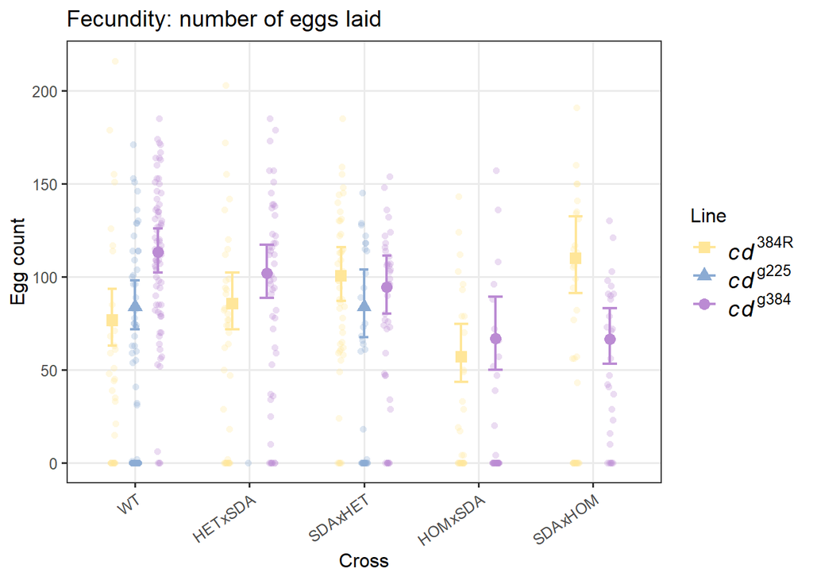

## Fertility

All comparisons are relative to WT. Most cross types within the cdg384 line did not differ significantly in hatching rate. A striking exception was the cdg384 SDA×HOM cross, which showed near-zero hatching relative to the reference (OR = 0.00, 95% CI: 0 - 0.01, p < 0.001), indicating that 1759 homozygous males are essentially sterile.

The single included cdg225 cross (SDA×HET) did differ significantly from the WT (OR = 0.15, p <0.001). In contrast, all tested cd384R crosses showed equal or higher hatching rates than the WT reference.

|  | cbind(larvae,(eggs-larvae)) |  |  |
| --- | --- | --- | --- |
| Predictors | Odds Ratios | CI | p |
| Intercept | 4.21 | 2.21 – 8.03 | **<0.001** |
| *cd*<sup>g225</sup> | 0.15 | 0.06 – 0.36 | **<0.001** |
| *cd*<sup>g384</sup> | 1.28 | 0.60 – 2.70 | 0.521 |
| HET×SDA | 2.02 | 0.83 – 4.89 | 0.121 |
| SDA×HET | 4.47 | 1.95 – 10.24 | **<0.001** |
| HOM×SDA | 1.92 | 0.68 – 5.41 | 0.214 |
| SDA×HOM | 2.95 | 1.15 – 7.59 | **0.025** |
| *cd*<sup>g384</sup> × HET×SDA | 0.32 | 0.11 – 0.93 | **0.037** |
| *cd*<sup>g384</sup> × SDA×HET | 0.15 | 0.05 – 0.43 | **<0.001** |
| *cd*<sup>g384</sup> × HOM×SDA | 0.30 | 0.07 – 1.24 | 0.097 |
| *cd*<sup>g384</sup> × SDA×HOM | 0.00 | 0.00 – 0.01 | **<0.001** |
| Random Effects |  |  |  |
| σ<sup>2</sup> | 2.56 |  |  |
| τ<sub>00</sub> <sub>plate_well:rep:line</sub> | 2.52 |  |  |
| τ<sub>00</sub> <sub>rep:line</sub> | 0.00 |  |  |
| τ<sub>00</sub> <sub>line</sub> | 0.00 |  |  |
| N <sub>plate_well</sub> | 354 |  |  |
| N <sub>rep</sub> | 10 |  |  |
| N <sub>line</sub> | 3 |  |  |
| Observations | 354 |  |  |
| Marginal R<sup>2</sup> / Conditional R<sup>2</sup> | 0.391 / NA |  |  |

```
# A tibble: 7 × 7
  contrast        cross   estimate    SE    df z.ratio  p.value
  <fct>           <fct>      <dbl> <dbl> <dbl>   <dbl>    <dbl>
1 QA383P - 1759   WT        -0.244 0.381   Inf  -0.641 5.21e- 1
2 QA383P - 1759   HETxSDA    0.909 0.400   Inf   2.27  2.32e- 2
3 QA383P - 2360B5 SDAxHET    1.92  0.456   Inf   4.20  8.03e- 5
4 QA383P - 1759   SDAxHET    1.67  0.392   Inf   4.25  6.22e- 5
5 2360B5 - 1759   SDAxHET   -0.250 0.469   Inf  -0.533 8.55e- 1
6 QA383P - 1759   HOMxSDA    0.970 0.624   Inf   1.55  1.20e- 1
7 QA383P - 1759   SDAxHOM    5.47  0.526   Inf  10.4   1.73e-14
```

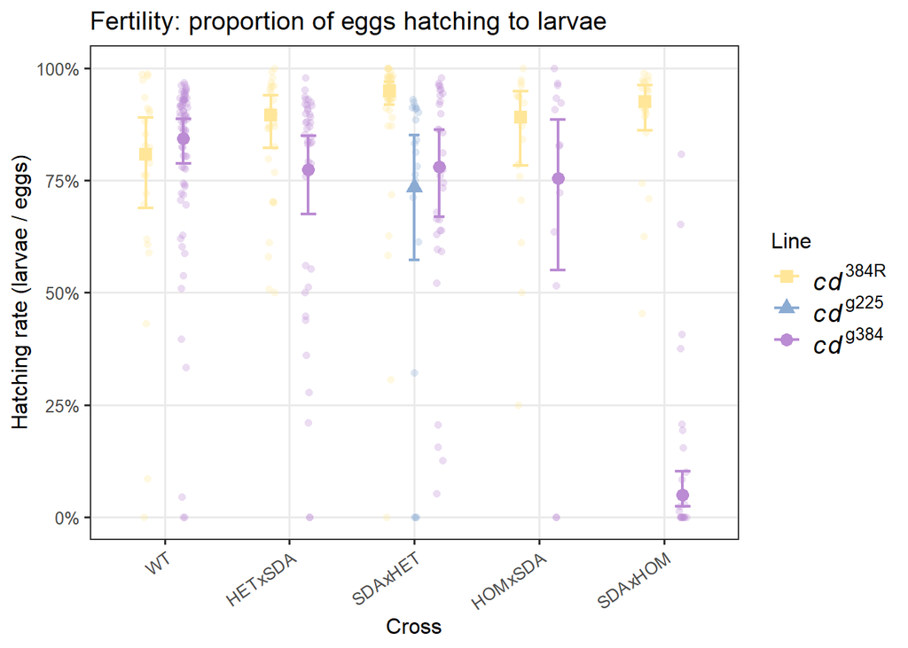

## Survival after Blood Feeding

Post-blood-feeding survival was modelled using a Weibull parametric survival model with a single combined line × genotype factor (n = 384). Model estimates are scale factors relative to the reference group (cd<sup>225R</sup> Hom); values below 1 indicate shorter survival relative to this reference.

```
`r2()` does not support models of class `flexsurvreg`.
```

[output not shown]

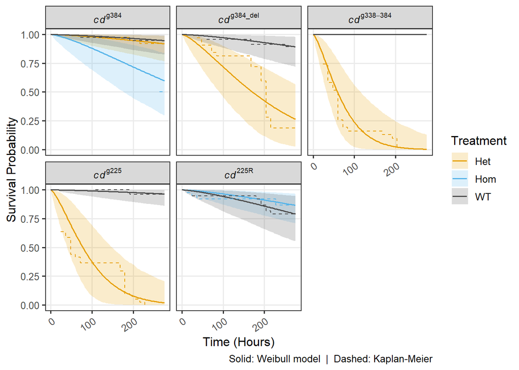

## TransHet survival

To assess whether the post-blood-feeding survival phenotype is caused by disruption of cardinal function, survival data were modelled for the 2360B5 and D251 lines specifically, using a Weibull parametric model (n = 186). Predictors were line (2360B5 vs D251) and genotype (Het, Hom, WT), with the reference group being 2360B5 Het.

D251 Het mosquitoes did not differ significantly from 2360B5 Het (estimate = 0.97, 95% CI: 0.40–2.34, p = 0.944). D251 WT mosquitoes showed dramatically extended survival relative to 2360B5 Het (estimate = 12218566.26, 95% CI: 0.00–Inf, p = 0.997), though the estimate is highly unstable, suggesting complete or near-complete separation in the data. Within the 2360B5 line, WT mosquitoes survived substantially longer than Het mosquitoes (estimate = 26.66, 95% CI: 11.04–64.38, p < 0.001). These results indicate that WT mosquitoes in both lines survive much longer than their KI heterozygote counterparts, but do not provide clear evidence that the D251 KO allele rescues the KI survival phenotype.

```
`r2()` does not support models of class `flexsurvreg`.
```

|  | Surv(Hours,event) |  |  |
| --- | --- | --- | --- |
| Predictors | Estimates | CI | p |
| shape | 1.335 | 0.411 – 4.334 | 0.630 |
| scale | 70.891 | 0.000 – 98038538547623231456082028620.000 | 0.894 |
| 2360B5 WT | 26.664 | 11.043 – 64.385 | **<0.001** |
| Trans-het (D251:2360 Het) | 0.969 | 0.401 – 2.340 | 0.944 |
| Het<sup>KO</sup> (D251:2360 WT) | 12218566.257 | 0.000 – Inf | 0.997 |
| Observations | 186 |  |  |

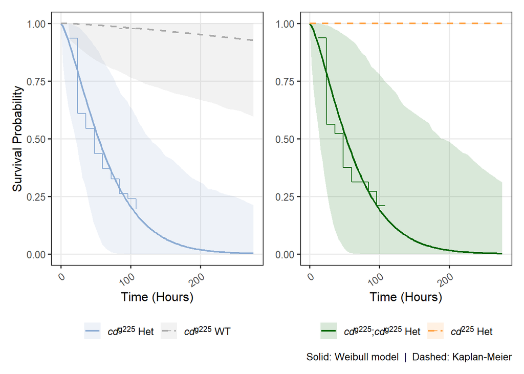

## Smurf assay

Midgut integrity was assessed using the smurf assay. The proportion of smurf-positive mosquitoes (indicating gut barrier disruption) was modelled using a binomial GLM with genotype (WT, KI, KO) as the sole predictor, restricted to sucrose-delivered mosquitoes (n = 9 cage-level observations). The reference group was WT.

KI mosquitoes had a dramatically elevated smurf rate compared to WT controls (OR = 65.6, 95% CI: 25.7–205.2, p < 0.001), confirming that the cardinal KI allele causes significant gut barrier disruption after blood feeding. The KO genotype showed a smurf rate consistent with zero events (OR ≈ 0, p = 0.996), reflecting complete separation with no observed smurf-positive cases in this genotype. Taken together, the data confirm that the KI phenotype is associated with midgut barrier disruption, while the KO allele does not share this defect.

[output not shown]

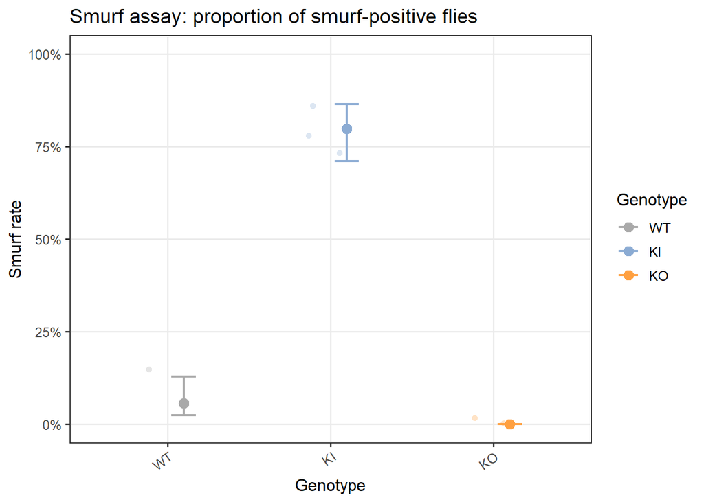

### Alternative figure as bar chart

```
`r2()` does not support models of class `flexsurvreg`.
```

[output not shown]

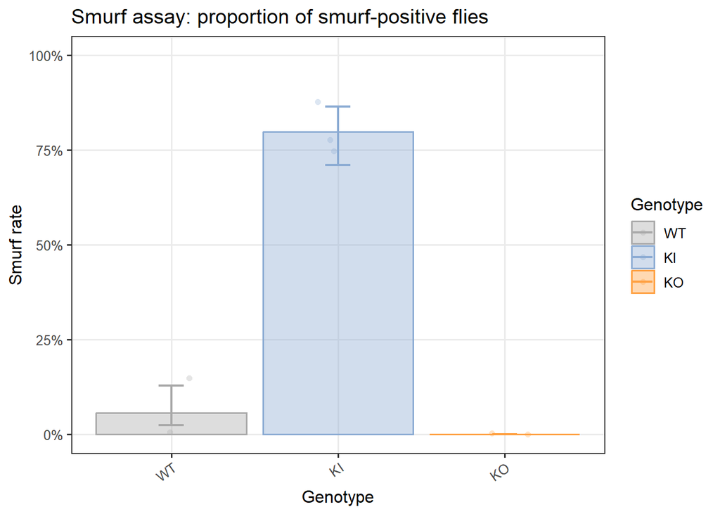

### Survival after Smurf

```
`r2()` does not support models of class `flexsurvreg`.
```

|  | Surv(hours,survival) |  |  |
| --- | --- | --- | --- |
| Predictors | Estimates | CI | p |
| shape | 2.75 | 0.40 – 18.98 | 0.305 |
| scale | 58.43 | 0.00 – 40818058648747196416.00 | 0.846 |
| line [KO] | 4900.99 | 0.00 – Inf | 0.998 |
| line [WT] | 4900.99 | 0.00 – Inf | 0.998 |
| Observations | 271 |  |  |

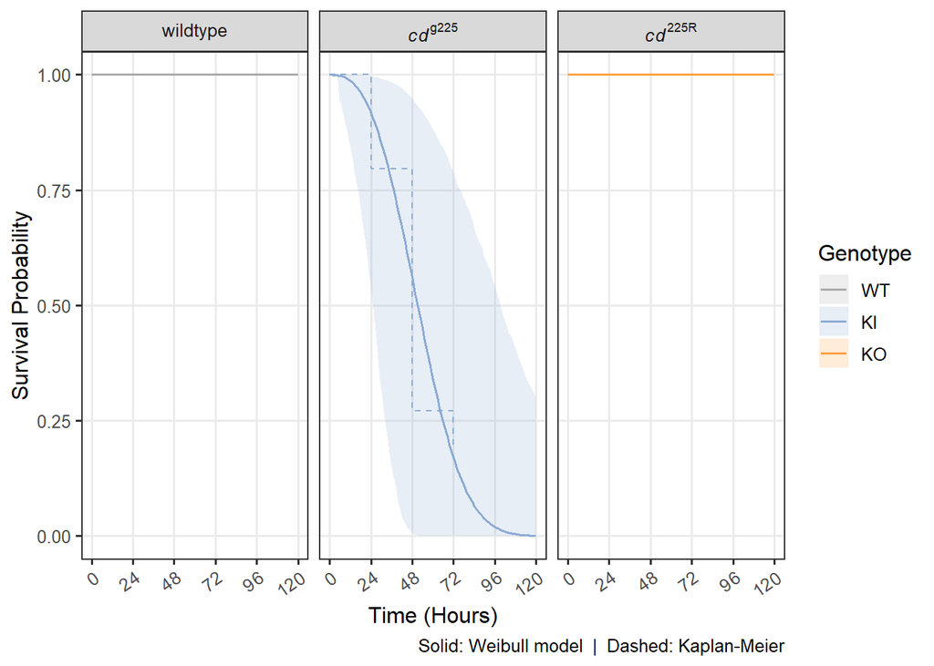

### Survival separated by smurf

```
`r2()` does not support models of class `flexsurvreg`.
```

|  | Surv(hours,survival) |  |  |
| --- | --- | --- | --- |
| Predictors | Estimates | CI | p |
| shape | 3.07 | 1.80 – 5.25 | **<0.001** |
| scale | 90.25 | 0.00 – 99042689238.77 | 0.672 |
| smurf [Smurf-positive] | 0.58 | 0.45 – 0.74 | **<0.001** |
| Observations | 104 |  |  |

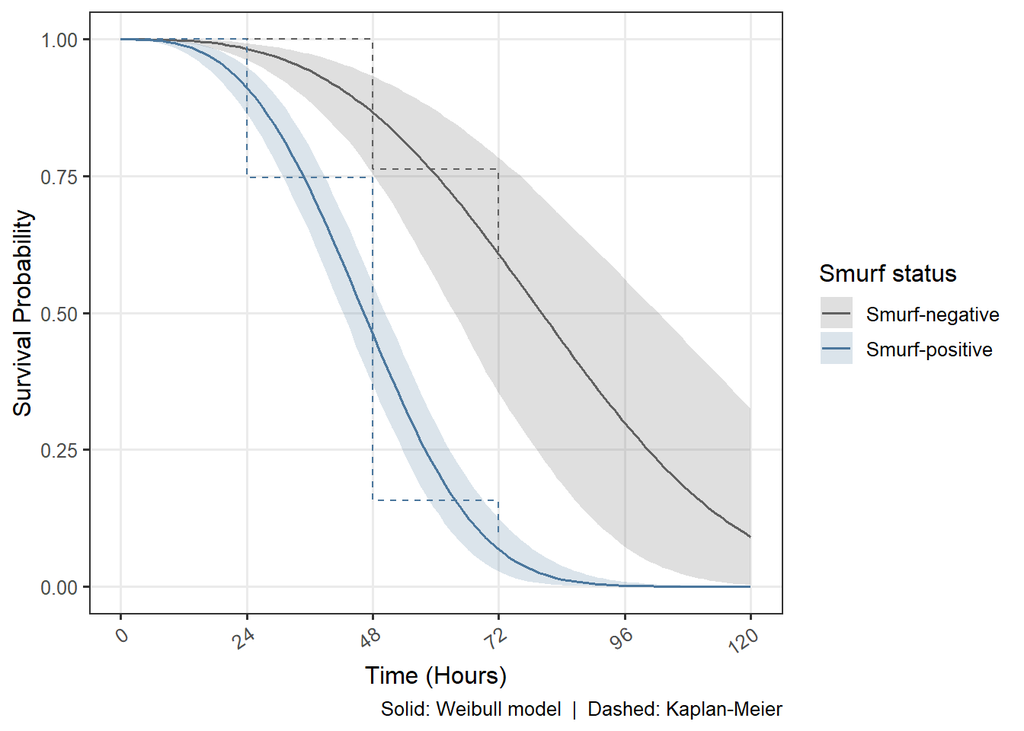

## XA Supplementation

```
`r2()` does not support models of class `flexsurvreg`.
```

|  | Surv(Hours,event) |  |  |
| --- | --- | --- | --- |
| Predictors | Estimates | CI | p |
| shape | 2.17 | 1.27 – 3.71 | **0.004** |
| scale | 94.74 | 0.00 – 258334014336.69 | 0.681 |
| Sugar supplementation | 1.65 | 1.27 – 2.15 | **<0.001** |
| 6 mM NaOH control | 0.92 | 0.69 – 1.21 | 0.534 |
| 6 mM XA | 1.64 | 1.15 – 2.35 | **0.006** |
| WT | 6.63 | 2.41 – 18.28 | **<0.001** |
| Observations | 244 |  |  |

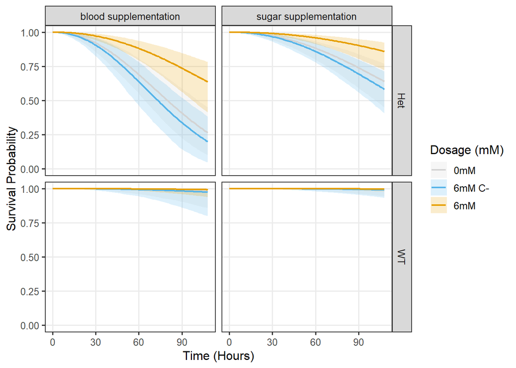

## Homozygous Survival

Adult eclosion was assessed from balanced crosses. The proportion of adults eclosing out of an expected 200 was modelled with a binomial GLM including line (1759 vs QA383P), genotype (HET, WT), sex, and all two- and three-way interactions (n = 16 observations; HOM observations excluded due to missingness). The reference cell was QA383P, HET, female.

The cd<sup>g384</sup> line (1759) did not differ significantly from QA383P in HET female eclosion rate (OR = 1.22, p = 0.157). WT females did not differ significantly from HET females in either line (OR = 0.95, p = 0.722). Neither sex nor any two- or three-way interaction reached statistical significance (all p > 0.16). These results indicate that, in the absence of homozygotes, eclosion rates are broadly similar between lines, genotypes, and sexes, and that no strong line-by-genotype or line-by-sex effects on HET/WT viability are detectable in this dataset.

|  | cbind(Adults,200-Adults) |  |  |
| --- | --- | --- | --- |
| Predictors | Odds Ratios | CI | p |
| Intercept (*cd*<sup>384R</sup> HET female) | 0.83 | 0.68 – 1.01 | 0.058 |
| Line (*cd*<sup>g384</sup> vs *cd*<sup>384R</sup>) | 1.22 | 0.93 – 1.61 | 0.157 |
| WT | 0.95 | 0.72 – 1.26 | 0.722 |
| Male | 1.15 | 0.87 – 1.52 | 0.321 |
| *cd*<sup>g384</sup> × WT | 0.79 | 0.53 – 1.17 | 0.230 |
| *cd*<sup>g384</sup> × Male | 0.76 | 0.51 – 1.12 | 0.161 |
| WT × Male | 1.20 | 0.81 – 1.78 | 0.368 |
| *cd*<sup>g384</sup> × WT × Male | 1.42 | 0.81 – 2.48 | 0.215 |
| Observations | 16 |  |  |

## qPCR

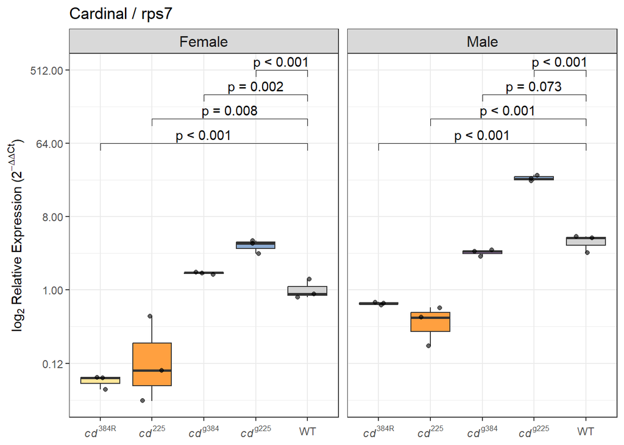

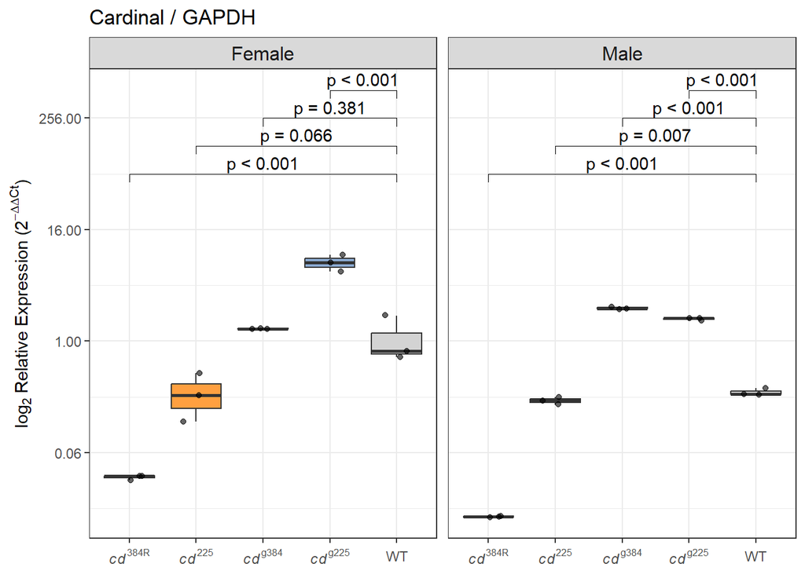